# Spatial Causal Inference

Author

Jiaxi Wu

```r
library(cmdstanr)
library(tidyverse)
library(INLA)
library(fmesher)
# library(rstan)
# rstan_options(auto_write = TRUE)
options(mc.cores=parallel::detectCores())
```

```r
gp_sample <- function(x, a2 = 1, l = 1, sigma2 = 0.1){
  n <- nrow(x)
  mu <- rep(0, n)
  K <- matrix(nrow = n, ncol = n)
  for (i in 1:(n - 1)) {
    K[i, i] = a2 + sigma2
    for (j in (i + 1):n) {
      K[i, j] = a2 * exp(-sum((x[i,] - x[j,])^2) / l)
      K[j, i] = K[i, j]
    }
  }
  K[n, n] = a2 + sigma2
  return(t(mvtnorm::rmvnorm(1, sigma = K)))
}
```

## Spatial causal inference setting

Let $T$ denote the treatment, $Y$ denote the outcome, $S$ denote the spatial coordinates, $U$ denote the unobserved spatial confounder, and $X$ denote the observed covariates. $S$ could possibly affect all the other variables and usually $U$ is not a fixed, measurable function of $S$, so the causal effect cannot be identified without additional assumptions if we adjust for $X$ and $S$ only [(Gilbert et al. 2021)](https://arxiv.org/pdf/2112.14946.pdf). In general, we assume exchangeability given $S,X,U$ (Assumption 3.4 in Gilbert et al. 2021) and positivity. We are interested in the average treatment effect $E[Y(t)]$ and $E[Y(t) \mid X,S]$.

### General omitted variable bias

We first consider the outcome model which is linear in $T$ [(Chernozhukov et al., 2022)](https://www.nber.org/system/files/working_papers/w30302/w30302.pdf): $Y = \beta T + f(X,S,U) + \epsilon$. $\beta$ is equal to the average causal effect or average causal derivative. Since $U$ is unobserved, the “short” regression with observed variables is $Y = \tilde{\beta}T + \tilde{f}(X,S) + \tilde{\epsilon}$. Let $\alpha=\frac{T-E[T|X,S,U]}{E(T-E[T|X,S,U])^2}$, $\tilde{\alpha} =\frac{T-E[T|X,S]}{E(T-E[T|X,S])^2}$, $g=E[Y|T,X,S,U]$, $\tilde{g}=E[Y|T,X,S]$, then $\beta=E[Y\alpha]=E[g\alpha]$, $\tilde{\beta}=E[Y\tilde{\alpha}] =E[\tilde{g}\tilde{\alpha}]$. The omitted variable bias is $\beta - \tilde{\beta} = E[(g - \tilde{g})(\alpha - \tilde{\alpha})]$ and it is bounded by

$$\begin{equation}
|\tilde{\beta} - \beta|^2 =\rho^2B^2\leq B^2,
\end{equation}$$

where $\rho^2 = Cor^2(g-\tilde{g}, \alpha-\tilde{\alpha})$, $B^2=E(g - \tilde{g})^2E(\alpha - \tilde{\alpha})^2$. $B^2$ can be further expressed as

$$\begin{equation}
B^2= S^2C_Y^2C_T^2,
\end{equation}$$

where $S^2 = E(Y-\tilde{g})^2E\tilde{\alpha}^2$ is identifiable, $C_Y^2 = R^2_{Y-\tilde{g}\sim g-\tilde{g}} = \eta_{Y\sim U\mid T,X,S}^2$, $C_T^2 = \frac{1-R^2_{\alpha \sim \tilde{\alpha}}}{R^2_{\alpha \sim \tilde{\alpha}}} = \frac{\eta_{T\sim U \mid X,S}^2}{1-\eta_{T\sim U\mid X,S}^2}$. There are three unidentified parameters $\rho^2$, $\eta_{T\sim U \mid X,S}^2$ and $\eta_{Y\sim U|T,X,S}^2$, which can be benchmarked empirically from observed data.

This result can be extended to fully nonparametric causal models and it only requires the target estimand $\beta:= Em(W,g)$ with $W=(T,X,S,U)$ to be a continuous linear functional of the conditional expectation function of the outcome, $g$. Then there exists unique Riesz representer $\alpha(W)$ such that $\beta= Em(W,g) = Eg(W)\alpha(W)$ and $\tilde{\alpha}(\tilde{W})=E[\alpha(W)\mid \tilde{W}]$ where $\tilde{W} = (T,X,S)$. For example, when the treatment is binary and the estimand is average causal effect $\beta=E[Y(1)-Y(0)]$, we have $\alpha(W) = \frac{1(T=1)}{P(T=1\mid X,S,U)} - \frac{1(T=0)}{P(T=0\mid X,S,U)}$. Another example is average causal derivatives for continuous treatment $\alpha(W) = -\partial_t \log f(T\mid X,S,U)$.

The OVB is still $\beta - \tilde{\beta} = E[(g - \tilde{g})(\alpha - \tilde{\alpha})]$ and it is bounded by $|\tilde{\beta} - \beta|^2 =\rho^2B^2\leq B^2$. The bound can be characterized by $B^2 = S^2C_Y^2C_T^2$ where $S^2$ and $C_Y^2$ have the same interpretations as above, but $C_T^2 = \frac{1-R^2_{\alpha \sim \tilde{\alpha}}}{R^2_{\alpha \sim \tilde{\alpha}}}$ has different forms under different cases. Take average causal effect with a binary treatment as example, $C_T^2 = \frac{E[1/(P(T=1 \mid X,S,U)P(T=0 \mid X,S,U))]}{E[1/(P(T=1 \mid X,S)P(T=0 \mid X,S))]} - 1$. For average causal derivatives, if $T$ is homoscedastic Gaussian conditional on $X$ and $(X,A)$, then $C_T^2$ simplifies to the one in partially linear model.

For inference, $S$ and $\tilde{\beta}$ in the bound can be estimated via debiased machine learning (DML), which can eliminate the regularization and overfitting bias. The DML estimators are asymptotically linear and Gaussian, so confidence bounds for the sensitivity bounds have asymptotic coverage.

Slides on [causal inference with machine learning](https://congress-files.s3.amazonaws.com/2022-09/Using%20Machine%20Learning%20for%20Causal%20Inference%20in%20Economics.pdf).

### Partially linear data generating process

Spatial modeling usually considers a partially linear model with spatial patterns modeled by Gaussian processes, splines or CAR processes:

$$\begin{align}
T &= \alpha_XX + \alpha_UU + Z + \delta, \\
Y &= \beta_TT + \beta_XX + \beta_UU + W + \epsilon,
\end{align}$$

where $Z$ and $W$ are spatial variables, but $U$ is not a fixed measurable function of $S,X$ so it is insufficient to adjust for $S,X$ only. We also assume $U = f(S) + V$, $V \sim N(0,\sigma^2)$, $\delta \sim N(0,\sigma_T^2)$, $\epsilon \sim N(0,\sigma_Y^2)$. The exogeneity variables are independent of all the other variables. Then

$$\begin{align}
T \mid S,X &\sim N(\alpha_XX + \alpha_Uf(S) + Z, \tilde{\sigma}_T^2 = \alpha_U^2\sigma^2 + \sigma_T^2), \\
U \mid T,S,X &\sim N(f(S) + w(T - \alpha_XX - \alpha_Uf(S) - Z), \sigma^2 - \alpha_Uw\sigma^2), \\
E[Y \mid T, S,X] &= \beta_TT + \beta_XX + \beta_UwT + \beta_U(1-\alpha_Uw)f(S) - \beta_Uw\alpha_XX - \beta_UwZ + W, \\
&= \tilde{\beta}_TT + \tilde{\beta}_XX - \beta_UwZ + W + \tilde{\beta}_U\tilde{f}(S). \\
Var(Y\mid T,S,X) &= \beta_U^2\sigma^2(1-\alpha_Uw) + \sigma_Y^2,
\end{align}$$

$$\begin{equation}
|\tilde{\beta}_T - \beta_T|^2 = E[(g - \tilde{g})(\alpha - \tilde{\alpha})]^2 = E(g - \tilde{g})^2E(\alpha - \tilde{\alpha})^2 = E(Y-\tilde{g})^2E\tilde{\alpha}^2 \eta_{Y\sim U|T,X,S}^2 \frac{\eta_{T\sim U|X,S}^2}{1-\eta_{T\sim U|X,S}^2}.
\end{equation}$$

This is because $g-\tilde{g} =E[Y\mid T,X,S,U] - E[Y\mid T,X,S]= \beta_U((1-\alpha_Uw)V-w\delta) = -\frac{\beta_U\sigma_T^2}{\alpha_U}(\alpha - \tilde{\alpha})$ and $\alpha - \tilde{\alpha} = \frac{\delta}{\sigma_T^2} - \frac{\alpha_U V+\delta}{\alpha_U^2\sigma^2+\sigma_T^2}$ are colinear. The bias can be characterized by $\eta_{Y\sim U|T,X,S}^2$ and $\eta_{T\sim U|X,S}^2$ without $\rho^2$. The partially linear model $Y_i=\beta T_i +g(S_i)+\epsilon_i$ can be identified under some smoothness assumptions ([Gilbert et al. 2023](https://arxiv.org/pdf/2308.12181.pdf)).

This result holds for the following DGP:

$$\begin{align}
U = f_U(X,S) + V, \\
T &= \alpha_UU + f_T(X,S) + \delta, \\
Y &= \beta_TT + \beta_UU + f_Y(X,S) + \epsilon,
\end{align}$$

which does not change $g-\tilde{g}$ and $\alpha - \tilde{\alpha}$. If $U$ does not enter $T$ and $Y$ linearly, $\rho^2$ may not be equal to $1$ and it becomes the above general case. On the other hand, if $Y$ is nonlinear in $T$, the estimand and form of $\alpha$ can be different and we need to discuss case by case.

### Spatial location only affects the unmeasured confounder

Suppose spatial location only affects potential outcomes and exposure through the unmeasured confounders (Gilbert et al. 2021 Assumptions 3.1 + 3.2 + 3.5, but no 3.3, which leads to non-identification), we focus on the partially linear model:

$$\begin{align}
U &= f(S) + V, V\sim N(0,\sigma^2), \\
T &= \alpha_XX + \alpha_UU + \delta, \\
Y &= \beta_TT + \beta_XX + \beta_UU + \epsilon.
\end{align}$$

If we fit $T \sim \alpha_XX + \tilde{f}(S) + \tilde{\delta}$ and $Y \sim \tilde{\beta}_TT + \tilde{\beta}_XX + \tilde{\beta}_U\tilde{f}(S) + \tilde{\epsilon}$ on observed data for this partially linear DGP, then the confounding bias can be characterized by a single sensitivity parameter $\eta^2_{T\sim U \mid X,S}$:

$$\begin{equation}
\tilde{\beta}_T - \beta_T = \beta_Uw = \tilde{\beta}_U\frac{\eta^2_{T\sim U \mid X,S}}{1 - \eta^2_{T\sim U \mid X,S}}.
\end{equation}$$

This result can be generalized to models that are nonlinear in $T$ and $X$. Simulation result is in overleaf.

### Replications at each $S$ and variables at different resolutions

If at each $S$, $U$ is invariant, but $T$, $Y$, $X$ are not, then case-control matching methods regress the difference between responses in the same region to remove spatial confounding. If $T_i$ (or $Y$) is invariant at location $i$ (treatment at the same scale as unmeasured confounders), the causal effect is not directly identified, but we may use $Y_{ij}-Y_{ik}$ or the outcome model to estimate $\sigma_Y^2$. Then $\eta_{Y\sim U|T,X,S}^2 = \frac{E(g - \tilde{g})^2}{E(Y - \tilde{g})^2} = \frac{E(g - \tilde{g})^2}{E(g - \tilde{g})^2 + \sigma_Y^2}$ is identified from $E(Y - \tilde{g})^2$ and $\sigma_Y^2$. This works for the general nonparametric model. For example, consider the PM2.5 in a region $S_i$ as the treatment, instead of $1$ kilometer resolution. This idea also works for areal data [(Reich et al., 2020)](https://arxiv.org/pdf/2007.02714.pdf). May related to clustered randomized trial, repeated measurements and mixed effect models.

Although we assume positivity for $T$ in the DGP, if we consider $S$ as a covariate and only observe a single $T_i$ for each $S_i$ (treatment does not vary at a smaller scale than the spatial confounder), a potential concern is that it leads to a practical (not structural) violation of positivity/overlap, which is unavoidable when the treatment is continuous and covariate space is high-dimensional [(Zhu et al., 2021)](https://www.ncbi.nlm.nih.gov/pmc/articles/PMC8492528/). In this case there is no data for us to learn about the counterfactuals at each location and we have to make some smoothness assumptions. The causal conclusions we make rely more on the model extrapolation and less on data itself (Section 3.2 in [Gilbert et al. 2021](https://arxiv.org/pdf/2112.14946.pdf) and [Gelman book, 2006](http://www.stat.columbia.edu/~gelman/arm/chap10.pdf)).

We omit covariates $X_{ij}$ for brevity or imagine they are absorbed by the functions of $S_i$. Consider the following data generating process with replications of observations at each location:

$$\begin{align}
U_i &= f(S_i) + V_i, \\
T_i &= \alpha_UU_i + Z_i + \delta_i, \\
Y_{ij} &= \beta_TT_i + \beta_UU_i + W_i + \epsilon_{ij},
\end{align}$$

where $Y_{ij}$ denotes the $j$th observation at location $i$, $Z_i=f_Z(S_i)$ and $W_i=f_W(S_i)$ are fixed, measurable functions of $S_i$, $V_i \sim N(0,\sigma^2)$, $\delta_i \sim N(0,\sigma_T^2)$, $\epsilon_i \sim N(0,\sigma_Y^2)$ are independent of each other and $S_i$. The estimand is $E[Y_{ij}(t+1)] - E[Y_{ij}(t)] = E[Y_i(t+1)\mid S_i=s] - E[Y_i(t)\mid S_i=s] = \beta_T$. Then

$$\begin{align}
T_i \mid S_i &\sim N(\alpha_U f(S_i) + Z_i, \tilde{\sigma}_T^2 = \alpha_U^2\sigma^2 + \sigma_T^2), \\
U_i \mid T_i,S_i &\sim N(f(S_i) + w(T_i - \alpha_Uf(S_i) - Z_i), \sigma^2(1 - \alpha_Uw)), \\
Y_{ij} \mid T_i,S_i &\sim N(\beta_TT_i + \beta_UwT_i + \beta_U(1-\alpha_Uw)f(S_i) - \beta_UwZ_i + W_i, \beta_U^2\sigma^2(1 - \alpha_Uw) + \sigma_Y^2) \\
&\sim N(\tilde{\beta}_TT_i + \tilde{\beta}_U\tilde{f}(S_i) - \beta_UwZ_i + W_i, \tilde{\sigma}_Y^2),
\end{align}$$

where $w=\frac{\alpha_U\sigma^2}{\alpha_U^2\sigma^2 + \sigma_T^2}$. We also need to account for the intraclass correlation $Cov(Y_{ij},Y_{ik}\mid T, S) = \beta_U^2Var(U_i\mid T_i,S_i) = \tilde{\sigma}_Y^2 - \sigma_Y^2$. Let $Y$ denote the vector of all the outcomes.

**Bias of $\tilde{\beta}_T$**

Fit models on observed data $T_i\mid S_i \overset{\mathrm{iid}}{\sim} N(\tilde{f}(S_i), \tilde{\sigma}_T^2)$ and $Y\mid T,S \sim N(\tilde{\beta}_TT + \tilde{h}(S),\Sigma)$ with GP priors on $\tilde{f}$ and $\tilde{h}$, $\Sigma$ following the above block diagonal structure. Then $\tilde{\sigma}_T^2$, $\tilde{\sigma}_Y^2$ and $\sigma_Y^2$ are identifiable and the bias is:

$$|\tilde{\beta}_T - \beta_T|^2 = E(Y-\tilde{g})^2E\tilde{\alpha}^2 \eta_{Y\sim U|T,X,S}^2 \frac{\eta_{T\sim U|X,S}^2}{1-\eta_{T\sim U|X,S}^2} = \frac{\tilde{\sigma}_Y^2 - \sigma_Y^2}{\tilde{\sigma}_T^2}\frac{\eta_{T\sim U \mid X,S}^2}{1-\eta_{T\sim U\mid X,S}^2}$$

Note that $\tilde{h}(S)$ are repeated measurements, so the GP prior should be assigned to non-repeated locations.

Another way of recovering $\sigma^2_Y$ is to fit a mixed effect model $Y_{ij} = \tilde{\beta}_TT_i + \tilde{h}(S_i) + \tilde{V}_i + \epsilon_{ij}$.

The idea about variables at different scale works for general hierarchical models [(Witty et al. 2020)](https://proceedings.mlr.press/v119/witty20a/witty20a.pdf). But this paper modeled entire treatment, outcome with GP.

#### Simulation

In the simulation, we generate data with $\beta_T = \beta_U =1, \sigma^2=\sigma_T^2=\sigma_Y^2=0.2$, so $\eta_{T\sim U\mid X,S}^2 =0.5, \tilde{\sigma}_T^2 = 0.4, \tilde{\sigma}_Y^2 = 0.3$. $f(S)$, $Z$ and $W$ are generated from GP. (If able to use sufficient statistics like average in location and variance can make computation easier.)

Follow the Bayesian workflow suggested in [Birthdays notebook](https://avehtari.github.io/casestudies/Birthdays/birthdays.html#Workflow_for_quick_iterative_model_building), we first use optimization and mcmc with small number of iterations for quick testing of the model. We check if $\tilde{\beta}_T$, $\tilde{\sigma}_T^2$, $\tilde{\sigma}_Y^2$ and $\sigma_Y^2$ can be consistently estimated by fitting models $T_i\mid S_i \overset{\mathrm{iid}}{\sim} N(\tilde{f}(S_i), \tilde{\sigma}_T^2)$ and $Y\mid T,S \sim N(\tilde{\beta}_TT + \tilde{h}(S),\Sigma)$ as above. :::

```r
# set.seed(111)
# estimate sigma_t_tilde
m <- 1000 # number of locations
s <- matrix(runif(2*m, -1, 1), ncol = 2)
u <- gp_sample(s, a2 = 1, l = 1, sigma2 = 0.2)
z <- gp_sample(s, a2 = 1, l = 2, sigma2 = 0.2)
t <- u + z # + rnorm(n, mean = 0, sd = sqrt(0.2))
data_list_t <- list(D=ncol(s), N=m, s=s[1:m,], t=t[1:m,])
trt_model <- cmdstan_model(stan_file = "stan/treatment_gp.stan")
trt_opt <- trt_model$optimize(data=data_list_t, init=2, refresh=1000, iter=10000)
```

```
Initial log joint probability = -325.119
    Iter      log prob        ||dx||      ||grad||       alpha      alpha0  # evals  Notes
      15      -89.7423   0.000167534    0.00871156      0.9961      0.9961       16
Optimization terminated normally:
  Convergence detected: relative gradient magnitude is below tolerance
Finished in  1.4 seconds.
```

```r
opt_draws <- trt_opt$draws()
cat("MAP of sigma_t_tilde_sq =", as.numeric(subset(opt_draws, variable=c('sigma_t')))^2)
```

```
MAP of sigma_t_tilde_sq = 0.4074218
```

```r
set.seed(123)
m <- 100 # number of locations
n <- 300
s <- matrix(runif(2*m, -1, 1), ncol = 2) # rep(s[,1], times=a)
u <- gp_sample(s, a2 = 1, l = 1, sigma2 = 0.2)
z <- gp_sample(s, a2 = 1, l = 2, sigma2 = 0.2)
w <- gp_sample(s, a2 = 1, l = 3, sigma2 = 0)
t <- u + z # + rnorm(m, mean = 0, sd = sqrt(0.2))
# s <- s[rep(1:nrow(s), each=n/m),]
u <- u[rep(1:nrow(u), each=n/m),]
t <- t[rep(1:nrow(t), each=n/m),]
w <- w[rep(1:nrow(w), each=n/m),]
# s <- do.call(rbind, replicate(5, s, simplify=FALSE))
# u <- do.call(rbind, replicate(5, u, simplify=FALSE))
# t <- do.call(rbind, replicate(5, t, simplify=FALSE))
y <- t + u + w + rnorm(n, mean = 0, sd = sqrt(0.2)) # + w

# plot
# u_density <- tibble(f = u, s1 = s[,1], s2 = s[,2])
# u_density %>%
#   ggplot(aes(x=s1, y=s2, color=f)) +
#   geom_point(alpha=1, size=2.5) +
#   theme_bw()

# # estimate sigma_y_tilde
# data_list_y <- list(D=ncol(s), N=length(y), s=s[rep(1:nrow(s), each=n/m),] , t=t, y=y)
# outcome_model <- cmdstan_model(stan_file = "outcome_gp.stan")
# outcome_opt <- outcome_model$optimize(data=data_list_y, init=2, refresh=100, iter=10000)
# opt_draws <- outcome_opt$draws()
# print(subset(opt_draws, variable=c('beta', 'sq_sigma_y')))

# MAP estimate of sigma_y_tilde and sigma_y
data_list <- list(D=ncol(s), M=m, N=length(y), s=s, t=t, y=y)
outcome_model_1 <- cmdstan_model(stan_file = "stan/replication_t_u.stan")
outcome_opt_1 <- outcome_model_1$optimize(data=data_list, init=2, refresh=500, iter=10000)
```

```
Initial log joint probability = -505.43
    Iter      log prob        ||dx||      ||grad||       alpha      alpha0  # evals  Notes
     499       103.834    0.00374776       3.22319      0.1965      0.1965      564
    Iter      log prob        ||dx||      ||grad||       alpha      alpha0  # evals  Notes
     999       104.167   9.55285e-05      0.164808      0.2635      0.2635     1094
    Iter      log prob        ||dx||      ||grad||       alpha      alpha0  # evals  Notes
    1499       104.178    0.00710096      0.283555           1           1     1612
    Iter      log prob        ||dx||      ||grad||       alpha      alpha0  # evals  Notes
    1742       104.182   0.000213397     0.0202186           1           1     1873
Optimization terminated normally:
  Convergence detected: relative gradient magnitude is below tolerance
Finished in  7.8 seconds.
```

```r
opt_draws <- outcome_opt_1$draws()
print(subset(opt_draws, variable=c('beta', 'sq_sigma_y', 'sq_sigma_y_tilde')))
```

```
# A draws_matrix: 1 iterations, 1 chains, and 3 variables
    variable
draw beta sq_sigma_y sq_sigma_y_tilde
   1  1.5       0.14             0.14
```

```r
# mcmc
run_sampler <- 0
if(run_sampler) {
  stan_results <- outcome_model_1$sample(data_list, iter_warmup = 1000,
                                         iter_sampling = 1000, refresh = 500)
  stan_results$save_object(file="simulation_rep_n300.RDS")
} else {
  stan_results <- readRDS("simulation_rep_n300.RDS")
}
result <- stan_results$summary(variables = c('beta', 'sq_sigma_y', 'sq_sigma_y_tilde'))
print(result)
```

```
# A tibble: 3 × 10
  variable         mean median     sd    mad    q5   q95  rhat ess_bulk ess_tail
  <chr>           <num>  <num>  <num>  <num> <num> <num> <num>    <num>    <num>
1 beta            1.49   1.49  0.0589 0.0586 1.39  1.58   1.00    5816.    3116.
2 sq_sigma_y      0.204  0.203 0.0200 0.0198 0.174 0.240  1.00    6093.    3273.
3 sq_sigma_y_til… 0.265  0.263 0.0253 0.0247 0.227 0.309  1.00    3555.    2843.
```

The posterior estimates are close to true values of $\tilde{\sigma}_T^2$, $\tilde{\beta}_T$, $\tilde{\sigma}_Y^2$ and $\sigma_Y^2$, and the $90\%$ credible intervals cover them.

Next we try faster approximate Bayesian inference using [R-INLA](https://www.r-inla.org/home). The continuous domain spatial modeling is done by stochastic partial differential equation (SPDE) approach. We first build a treatment model.

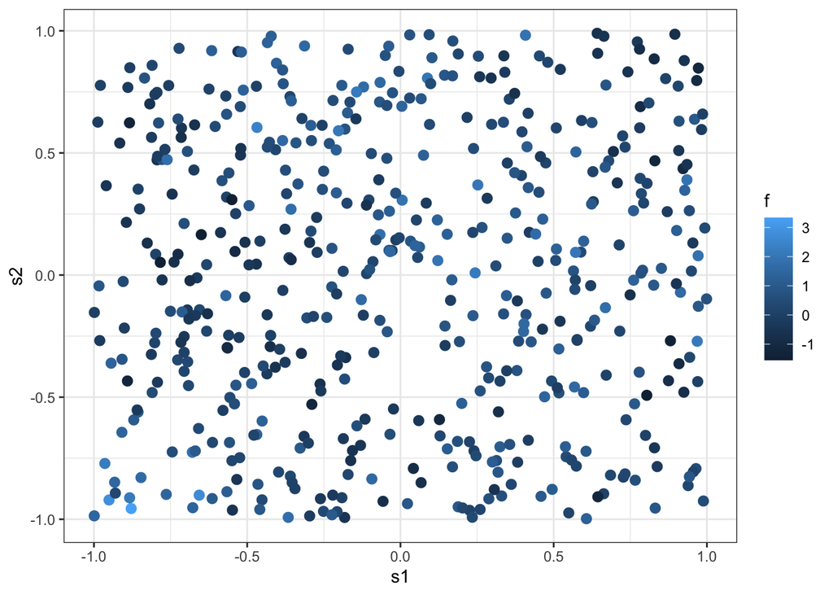

```r
set.seed(123)
n <- 500 # number of locations
s <- matrix(runif(2*n, -1, 1), ncol = 2)
u <- gp_sample(s, a2 = 1, l = 1, sigma2 = 0.2)
z <- gp_sample(s, a2 = 1, l = 2, sigma2 = 0.2)
t <- u + z # + rnorm(n, mean = 0, sd = sqrt(0.2))
# data1 <- data.frame(s1 = s[,1], s2 = s[,2], t = t)
# plot
tibble(f = t, s1 = s[,1], s2 = s[,2]) %>%
  ggplot(aes(x=s1, y=s2, color=f)) +
  geom_point(alpha=1, size=2.5) +
  theme_bw()
```

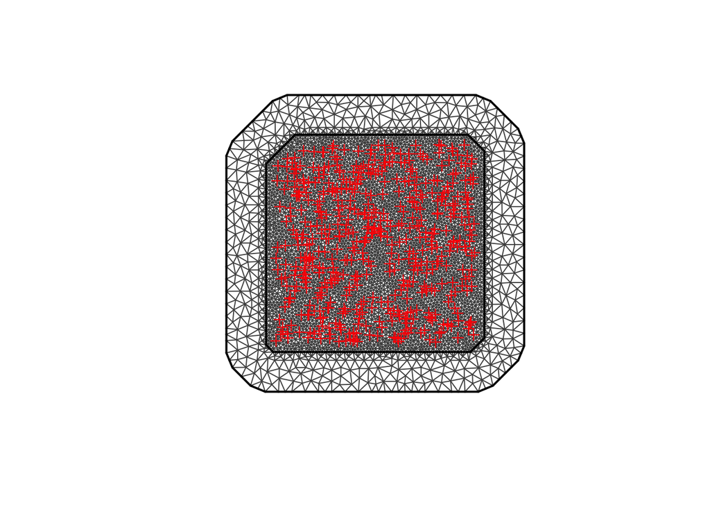

```r
# use fmesher to create meshes, tradeoff between accuracy and computational cost
mesh1 <- fm_mesh_2d_inla(loc=s, max.edge=c(0.05, 0.15), cutoff=0.02, offset=c(0.1,0.4))
plot(mesh1)
points(s, pch=3, bg=1, col="red", cex=1)
```

```r
# create projector matrix A, mapping triangulation vertices on mesh to observation locations
A.est <- inla.spde.make.A(mesh=mesh1, loc=s)
print(dim(A.est)) # number of data locations * number of mesh nodes
```

```
[1]  500 5390
```

```r
# fit model
spde <- inla.spde2.matern(mesh=mesh1, alpha=2)
formula <- y ~ -1 + intercept + f(spatial.field, model=spde)
# spatial.field is a index variable?
result <- inla(formula,
               data = list(y=t[,1], intercept=rep(1, spde$n.spde),
               spatial.field=1:spde$n.spde),
               control.predictor=list(A=A.est, compute=TRUE))

# round(result$summary.fixed, 3)
print(round(result$summary.hyperpar, 3))
```

```
                                          mean    sd 0.025quant 0.5quant
Precision for the Gaussian observations  2.456 0.164      2.145    2.451
Theta1 for spatial.field                -1.217 0.216     -1.618   -1.224
Theta2 for spatial.field                 0.184 0.524     -0.940    0.215
                                        0.975quant   mode
Precision for the Gaussian observations      2.792  2.445
Theta1 for spatial.field                    -0.770 -1.259
Theta2 for spatial.field                     1.111  0.366
```

```r
cat("posterior mean of sigma_t_tilde_sq =", inla.emarginal(function(x) 1/x, result$marginals.hyper[[1]])) # posterior mean of variance
```

```
posterior mean of sigma_t_tilde_sq = 0.409005
```

Posterior mean is close to $0.4$ and $95\%$ credible interval covers true $\tilde{\sigma}_T^2$.

Then we check the posterior distributions of $\tilde{\beta}_T$, $\tilde{\sigma}_Y^2$ and $\sigma_Y^2$ by fitting $Y_{ij} = \beta_0 + \tilde{\beta}_TT_i + \tilde{h}(S_i) + \tilde{V}_i + \epsilon_{ij}$ without marginalizing out $U_i$. The random effect $\tilde{V}_i$ accounts for the between-group variation $\beta_U^2Var(U_i \mid T_i,S_i)= \tilde{\sigma}_Y^2 -\sigma_Y^2 =0.1$.

```r
# with replicates at each location
set.seed(111)
m <- 100 # number of locations
n <- 500
s <- matrix(runif(2*m, -1, 1), ncol = 2) # rep(s[,1], times=a)
group <- rep(1:m, each=n/m)
u <- gp_sample(s, a2 = 1, l = 1, sigma2 = 0.2)
z <- gp_sample(s, a2 = 1, l = 2, sigma2 = 0.2)
w <- gp_sample(s, a2 = 1, l = 3, sigma2 = 0)
t <- u + z # + rnorm(m, mean = 0, sd = sqrt(0.2))
u <- u[rep(1:nrow(u), each=n/m),]
t <- t[rep(1:nrow(t), each=n/m),]
w <- w[rep(1:nrow(w), each=n/m),]
y <- t + u + w + rnorm(n, mean = 0, sd = sqrt(0.2))

mesh <- fm_mesh_2d_inla(loc=s, max.edge=c(0.05, 0.2), offset=c(0.1,0.4))

# For each observation, index gives the corresponding index into the matrix of measurement locations, and repl determines the corresponding replicate index.
A <- inla.spde.make.A(mesh, loc = s, index = rep(1:m, each = n/m),
                      repl = rep(1:(n/m), times = m))
print(dim(A))
```

```
[1]   500 25440
```

```r
spde <- inla.spde2.matern(mesh=mesh, alpha=2)

# index the full mesh and replicates
mesh.index <- inla.spde.make.index(name = "field", n.spde = spde$n.spde,
                                   n.repl = n/m)

# stack the predictor information
stack <- inla.stack(data = list(y = y), A = list(A, 1),
                    effects = list(c(mesh.index, list(intercept = 1)),
                                   list(cov = t, loc = group)), tag = "est")

# fit model
formula <- y ~ -1 + intercept + cov + f(field, model = spde, replicate = field.repl) + f(loc, model = "iid")
rep_result <- inla(formula, data = inla.stack.data(stack, spde = spde),
                   family = "normal",
                   control.predictor = list(A = inla.stack.A(stack),
                                             compute = TRUE))
print(round(rep_result$summary.fixed, 3))
```

```
            mean   sd 0.025quant 0.5quant 0.975quant   mode kld
intercept -0.372 0.85     -2.157   -0.371      1.404 -0.371   0
cov        1.513 0.05      1.414    1.513      1.610  1.513   0
```

```r
print(round(rep_result$summary.hyperpar, 3))
```

```
                                          mean    sd 0.025quant 0.5quant
Precision for the Gaussian observations  5.453 0.432      4.648    5.438
Theta1 for field                        -0.803 0.155     -1.105   -0.804
Theta2 for field                        -0.337 0.262     -0.860   -0.334
Precision for loc                       10.417 2.481      6.386   10.133
                                        0.975quant   mode
Precision for the Gaussian observations      6.346  5.412
Theta1 for field                            -0.496 -0.807
Theta2 for field                             0.170 -0.321
Precision for loc                           16.097  9.585
```

```r
cat("posterior mean of sigma_y_tilde_sq - sigma_y_sq =", inla.emarginal(function(x) 1/x, rep_result$marginals.hyper[[4]]), '\n')
```

```
posterior mean of sigma_y_tilde_sq - sigma_y_sq = 0.1014277
```

```r
cat("posterior mean of sigma_y_sq =", inla.emarginal(function(x) 1/x, rep_result$marginals.hyper[[1]]))
```

```
posterior mean of sigma_y_sq = 0.1845262
```

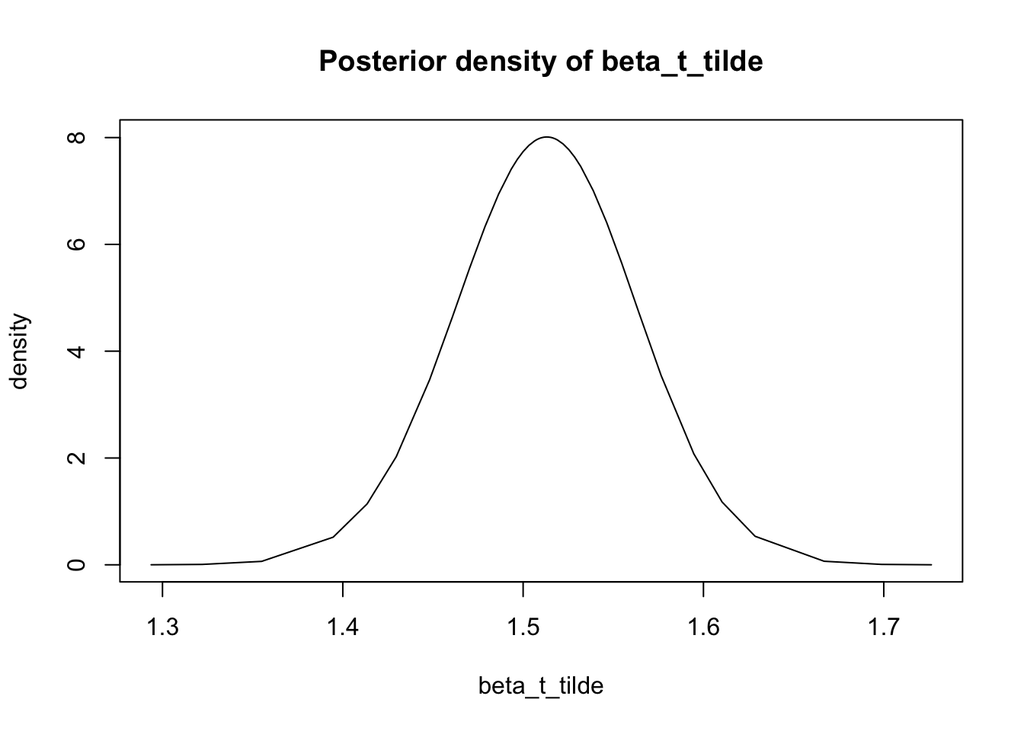

```r
posterior_beta_tilde <- rep_result$marginals.fixed[[2]]
plot(posterior_beta_tilde, type = "l", xlab = 'beta_t_tilde', ylab = 'density',
     main = "Posterior density of beta_t_tilde")
```

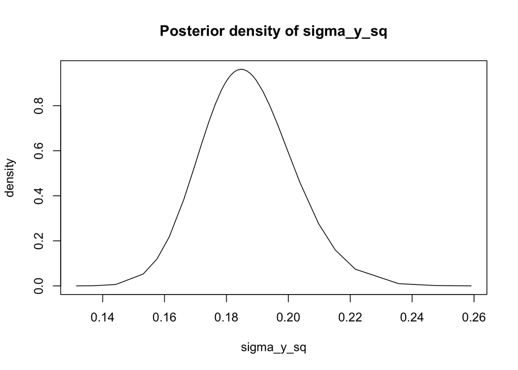

```r
posterior_sigma_y_sq <- rep_result$marginals.hyperpar[[1]]
posterior_sigma_y_sq[,1] <- 1 / posterior_sigma_y_sq[,1]
plot(posterior_sigma_y_sq, type = "l", xlab = 'sigma_y_sq', ylab = 'density',
     main = "Posterior density of sigma_y_sq")
```

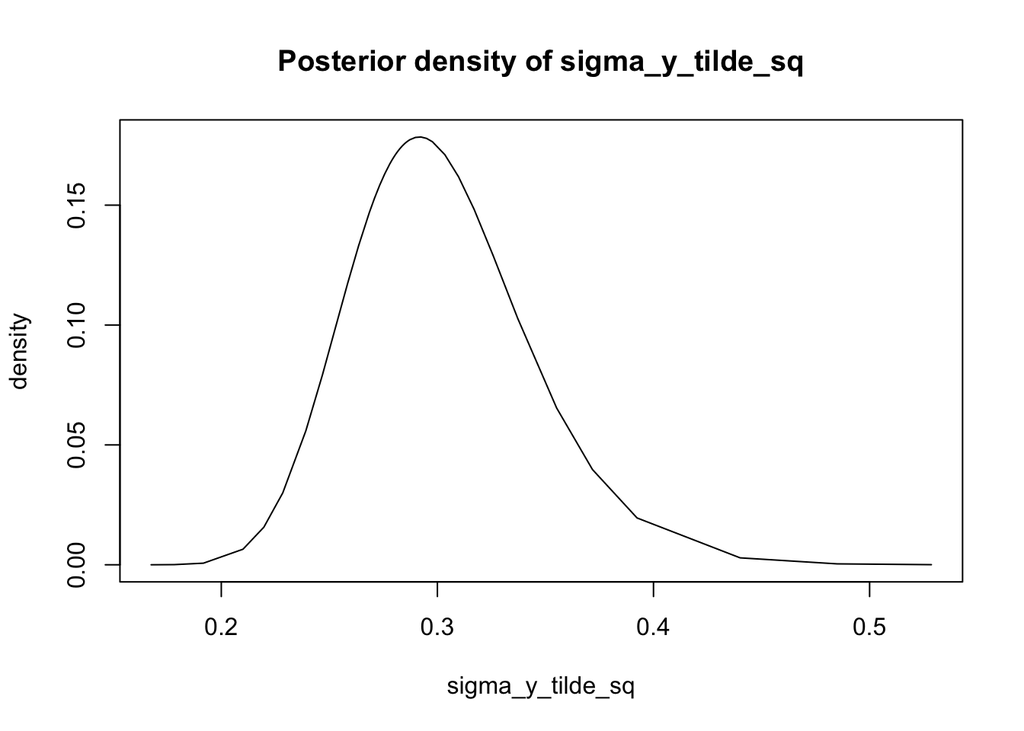

```r
posterior_sigma_y_tilde_sq <- rep_result$marginals.hyperpar[[4]]
posterior_sigma_y_tilde_sq[,1] <- 1 / posterior_sigma_y_tilde_sq[,1] +
  posterior_sigma_y_sq[,1]
plot(posterior_sigma_y_tilde_sq, type = "l", xlab = 'sigma_y_tilde_sq', ylab = 'density',
     main = "Posterior density of sigma_y_tilde_sq")
```

The $95\%$ credible intervals cover true $\tilde{\beta}_T, \tilde{\sigma}_Y^2-\sigma_Y^2, \sigma_Y^2$.

### When treatment effect is identified

$U$ is a fixed, measurable function of $S$. Or $U$ is fixed at each location, but $T$ and $Y$ are not.

### Areal data

Replace the $f$ in $U_i=f(S_i)+V_i$ by a CAR process. Identifiability of CAR processes? Perform sensitivity analysis based on residual variances.

### Application

PM2.5 on birthweight [(Gilbert et al. 2021)](https://arxiv.org/pdf/2112.14946.pdf), consider treatment and spatial location at the same resolution.

[(Witty et al. 2020)](https://proceedings.mlr.press/v119/witty20a/witty20a.pdf) duplicate data instances with real treatments, covariates, confounders and a synthetic outcome function to make a synthetic dataset. Or preserves outcome functions from real quasi-experimental data, and uses biased sampling to induce confounding.

# more general model

nonlinear in T,X? interaction?